# Assignment_6

## Assignment 06

```python
import numpy as np
import random as rand
import torch
import torch.nn as nn
import torch.nn.functional as F
import torchvision.datasets as dsets
import torchvision.transforms as transforms
from torch.optim.lr_scheduler import ReduceLROnPlateau
import matplotlib.pyplot as plt
import os
import time
from tqdm.notebook import tqdm

import warnings
warnings.filterwarnings("ignore", category=DeprecationWarning)
```

```python
from trainer import Trainer
from models import VanillaVAE, ConvVAE
from utils import plot_history, reject_randomness, sample_interpolation, display_projections
```

```python
reject_randomness(2021)
```

```python
data_transforms = transforms.Compose([
    transforms.ToTensor()
])

trainset = dsets.CIFAR10('data', train=True, download=True, transform=data_transforms)
validset = dsets.CIFAR10('data', train=False, download=True, transform=data_transforms)

BATCH_SIZE = 128
train_loader = torch.utils.data.DataLoader(dataset=trainset, batch_size=BATCH_SIZE, shuffle=True, num_workers=14)
valid_loader = torch.utils.data.DataLoader(dataset=validset, batch_size=BATCH_SIZE, shuffle=False, num_workers=14)
```

```
Files already downloaded and verified
Files already downloaded and verified
```

### Loss functions

Please find a short overview of the loss functions below. There is nothing special happening here, some further, unimportant info is in the code comments.

```python
# kl_loss, like discussed
def kl_loss(x, target):
    recons, (z, mu, log_var) = x
    return (mu**2 + log_var.exp() - 1 - log_var).mean() * 0.5

# reconstruction loss, BCE didn't work so well so we switch to smooth L1
def reconstruction_loss(x, target):
    recons, (z, mu, log_var) = x
    #return nn.BCEWithLogitsLoss()(recons, target)
    x_hat = torch.sigmoid(recons)
    return F.smooth_l1_loss(x_hat,target)

# dssim used to augment the reconstruction loss to produce more visually plausible images
# uncomment this so this notebook doesn't need kornia
#def dssim(x, target):
#    recons, (z, mu, log_var) = x
#    x_hat = torch.sigmoid(recons)
#    return ssim_loss(x_hat, target, 5)

# perceptual loss, just the mean of the normalized distances between the activations in the first 5 feature maps
# of a pre-trained VGG for some reconstruction and target. We need to normalize all inputs to match the VGG training
# using https://github.com/chenyaofo/pytorch-cifar-models
# we assume these models are trained on normalized cifar images
# finally verified at https://github.com/chenyaofo/image-classification-codebase/blob/master/codebase/data/cifar.py
mean = [0.5, 0.5, 0.5]
std = [0.5, 0.5, 0.5]
normalize = transforms.Normalize(mean, std)

def get_vgg_features():
    model = torch.hub.load("chenyaofo/pytorch-cifar-models", "cifar10_vgg11_bn", pretrained=True)
    model.features.requires_grad_(False)
    return model.features

class PERCEPTUAL_LOSS(nn.Module):
    def __init__(self):
        super(PERCEPTUAL_LOSS, self).__init__()
        self.device = torch.device("cuda" if torch.cuda.is_available() else "cpu")
        # get feature network from pretrained VGG
        self.features = get_vgg_features().to(self.device)
        # identifies the first 5 VGG blocks
        self.layers = [(0,3),(4,7),(8,10),(11,14),(15,17)]

    def forward(self, x, target):
        x_out, target_out = [], []
        (x_in, _), target_in = x, target
        x_in, target_in = normalize(torch.sigmoid(x_in)), normalize(target_in)
        # get feature maps for each layer, normalize and cache them
        for layer in self.layers:
            x_in = self.features[layer[0]:layer[1]+1](x_in)
            target_in = self.features[layer[0]:layer[1]+1](target_in)
            x_out.append(x_in / (torch.linalg.norm(x_in,dim=(-2,-1), keepdim=True) + 1e-12))
            target_out.append(target_in / (torch.linalg.norm(target_in,dim=(-2,-1), keepdim=True) + 1e-12))
        l = 0.
        # get weighted sum over feature map distances
        for i in range(len(x_out)):
            b, c, h, w = x_out[i].shape
            l += torch.sum((x_out[i]-target_out[i])**2, dim=(1,2,3))/(h*w)
        return l.mean()/len(x_out)

# This criterion combines kl, reconstruction, perceptual and dssim loss terms
# Training was very sensitive to the kl loss weight, see below
class VAE_CRITERION(nn.Module):
    def __init__(self, lambda_kl=1., lambda_r=1., lambda_p=0., lambda_dssim=0.):
        super(VAE_CRITERION, self).__init__()
        self.percept_loss = PERCEPTUAL_LOSS()
        self.lambda_kl = lambda_kl
        self.lambda_r = lambda_r
        self.lambda_p = lambda_p
        self.lambda_dssim = lambda_dssim
    def forward(self, x, target):
        recons_loss = reconstruction_loss(x, target)
        kl = kl_loss(x, target)
        if self.lambda_p > 0.:
            percept_loss = self.percept_loss(x, target)
        else:
            percept_loss = 0.
        if self.lambda_dssim > 0.:
            struct_loss = dssim(x, target)
        else:
            struct_loss = 0.
        loss = self.lambda_r*recons_loss + self.lambda_kl*kl + self.lambda_p*percept_loss + self.lambda_dssim*struct_loss
        return loss

# The subtext to figure 6 and section 'Understanding the effects of beta' in
# https://openreview.net/pdf?id=Sy2fzU9gl
# suggests that the weight of the KL-term should be normalized with respect to latent and input dimensions.
# We believe this is a good appraoch, and observe that a high weight here will imediately collapse the model
# to zero KL loss, which comes at the cost of bad reconstruction performance.

# Example set of hyperparameters used for training:
BETA = 8
LATENT_DIM = 28
LR = 1e-4
criterion = VAE_CRITERION(lambda_kl=BETA*LATENT_DIM/(3*32*32), lambda_r=10., lambda_dssim=1., lambda_p=0)
```

```
Using cache found in /home/jannogga/.cache/torch/hub/chenyaofo_pytorch-cifar-models_master
```

### Training the models

In our ConvVAE, we used a CIFAR10-pretrained Resnet encoder from the same source as the VGG. In a warm-up procedure of a maximum of 30 episodes, this encoder is frozen and just $\mu$, $\log \sigma$ as well as the decoder are trained. Then, for a maximum of 250 episodes, the entire network is trained together. This greatly improved training stability, which was otherwise a challenge. In practice, the training session for each model were much shorter than the maximum epochs due to early stopping based on the validation loss.

Below, please find the summary over some training runs we conducted for different models and different losses. Note that the first 4 training processes just track, but to not optimize the perceptual loss.

### Training 1 - ConvVAE with interpolate + conv upsample

The article at https://distill.pub/2016/deconv-checkerboard/ suggests that artifacts typically seen for transpose convolution layers could be avoided using upsampling and consecutive smoothing via one convolutional layer. Therefore, we also include this approach in our evaluation. We print the model parameters twice to show how the model parameters are spread between encoder and decoder, which are supposed to be relatively symmetrical.

This type of model seems to be our most effective one.

```
Using cache found in /home/jannogga/.cache/torch/hub/chenyaofo_pytorch-cifar-models_master
```

```
Number of model parameters with frozen encoder: 418293
```

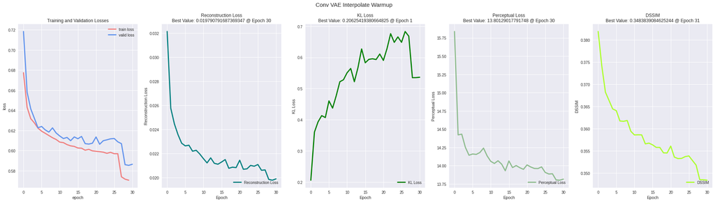

```
Number of model parameters: 690117
```

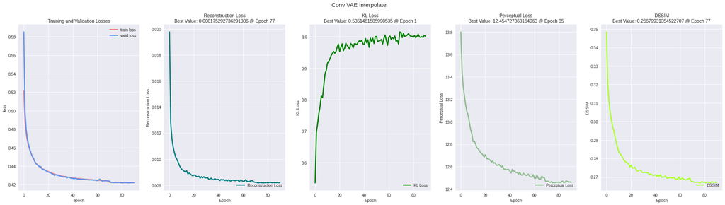

```python
model = ConvVAE(z_dim=LATENT_DIM, mode='upConv')
model.freeze_encoder()

title = 'Conv VAE Interpolate'
print('Number of model parameters with frozen encoder:', sum(p.numel() for p in model.parameters() if p.requires_grad))
conv_vae_trainer_warmup = Trainer(model, criterion, train_loader, valid_loader,   description=title+' Warmup', lr=LR*10, n_epochs=30)
conv_vae_trainer_warmup.load_model()
plot_history(conv_vae_trainer_warmup)
model = conv_vae_trainer_warmup.model
model.unfreeze_encoder()
print('Number of model parameters:', sum(p.numel() for p in model.parameters() if p.requires_grad))
interpolate_vae_trainer = Trainer(model, criterion, train_loader, valid_loader,   description=title, lr=LR)
interpolate_vae_trainer.load_model()
plot_history(interpolate_vae_trainer)
```

### Training 2 - ConvVAE with PixelShuffle upsample

This model uses PixelShuffle in the decoder. While the training curves look similar for this model, the results were visually not as good as using the interpolation plus convolution as above.

```
Using cache found in /home/jannogga/.cache/torch/hub/chenyaofo_pytorch-cifar-models_master
```

```
Number of model parameters with frozen encoder: 405637
```

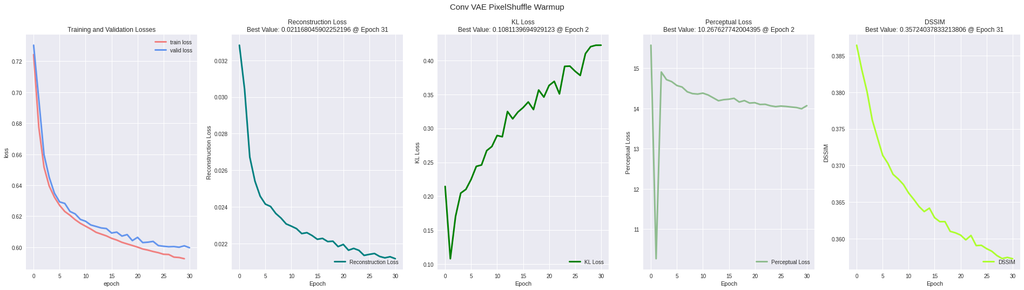

```
Number of model parameters: 677461
```

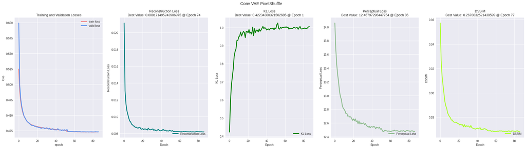

```python
model = ConvVAE(z_dim=LATENT_DIM, mode='pixelShuffle')
model.freeze_encoder()
title = 'Conv VAE PixelShuffle'
print('Number of model parameters with frozen encoder:', sum(p.numel() for p in model.parameters() if p.requires_grad))
conv_vae_trainer_warmup = Trainer(model, criterion, train_loader, valid_loader,   description=title+' Warmup', lr=LR*2, n_epochs=30)
conv_vae_trainer_warmup.load_model()
plot_history(conv_vae_trainer_warmup)
model = conv_vae_trainer_warmup.model
model.unfreeze_encoder()
print('Number of model parameters:', sum(p.numel() for p in model.parameters() if p.requires_grad))
conv_vae_trainer = Trainer(model, criterion, train_loader, valid_loader,   description=title, lr=LR)
conv_vae_trainer.load_model()
plot_history(conv_vae_trainer)
```

### Training 3 - ConvVAE with transpose conv upsample

```
Using cache found in /home/jannogga/.cache/torch/hub/chenyaofo_pytorch-cifar-models_master
```

```
Number of model parameters with frozen encoder: 397813
```

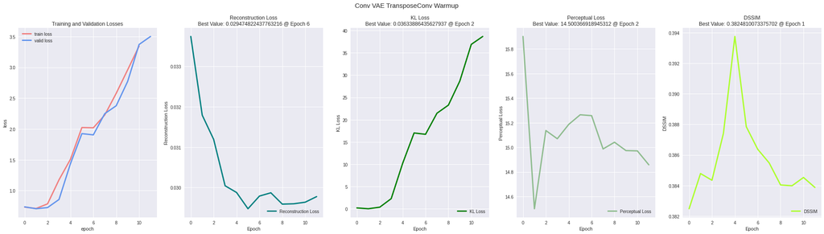

```
Number of model parameters: 669637
```

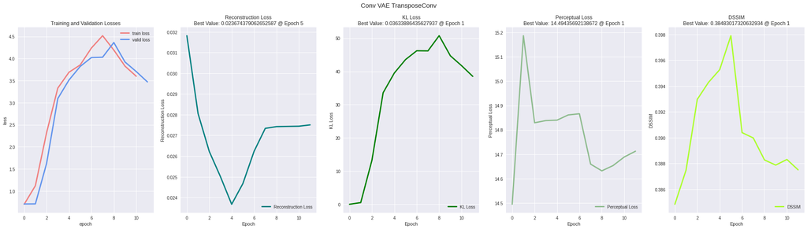

```python
model = ConvVAE(z_dim=LATENT_DIM, mode='deConv')
model.freeze_encoder()
title = 'Conv VAE TransposeConv'
print('Number of model parameters with frozen encoder:', sum(p.numel() for p in model.parameters() if p.requires_grad))
conv_vae_trainer_warmup = Trainer(model, criterion, train_loader, valid_loader,   description=title+' Warmup', lr=LR*2, n_epochs=30)
conv_vae_trainer_warmup.load_model()
plot_history(conv_vae_trainer_warmup)
model = conv_vae_trainer_warmup.model
model.unfreeze_encoder()
print('Number of model parameters:', sum(p.numel() for p in model.parameters() if p.requires_grad))
conv_vae_trainer = Trainer(model, criterion, train_loader, valid_loader,   description=title, lr=LR)
conv_vae_trainer.load_model()
plot_history(conv_vae_trainer)
```

### Training 4 - VAE from Class

This model is trained without warmup as we aren't using a pre-trained encoder here. The training process was stable, but the results are visually much worse than for the first two models.

```
Number of model parameters: 3291960
```

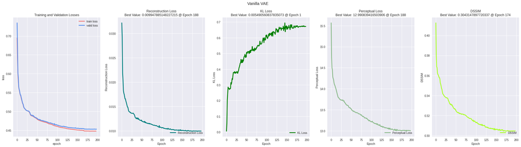

```python
from models import VanillaVAE
model = VanillaVAE(in_size=(3,32,32), sizes=[3072, 512, 128, LATENT_DIM], act="ReLU")
print('Number of model parameters:', sum(p.numel() for p in model.parameters() if p.requires_grad))
title = 'Vanilla VAE'
vanilla_vae_trainer = Trainer(model, criterion, train_loader, valid_loader,   es_mode='min', description=title, lr=LR)
vanilla_vae_trainer.load_model()
plot_history(vanilla_vae_trainer)
```

### Training 5 - Retraining a Model optimizing Perceptual Loss

Since our interpolation and then convolution upsample model worked best, we train it again using a weight of $0.05$ for the perceptual loss...

```
Using cache found in /home/jannogga/.cache/torch/hub/chenyaofo_pytorch-cifar-models_master
Using cache found in /home/jannogga/.cache/torch/hub/chenyaofo_pytorch-cifar-models_master
```

```
Number of model parameters with frozen encoder: 418293
```

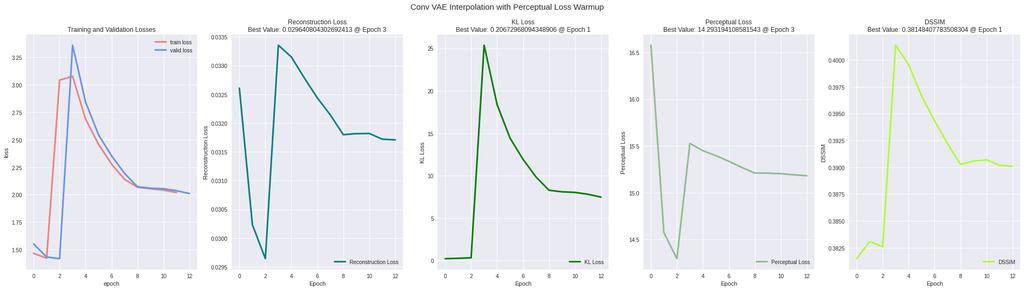

```
Number of model parameters: 690117
```

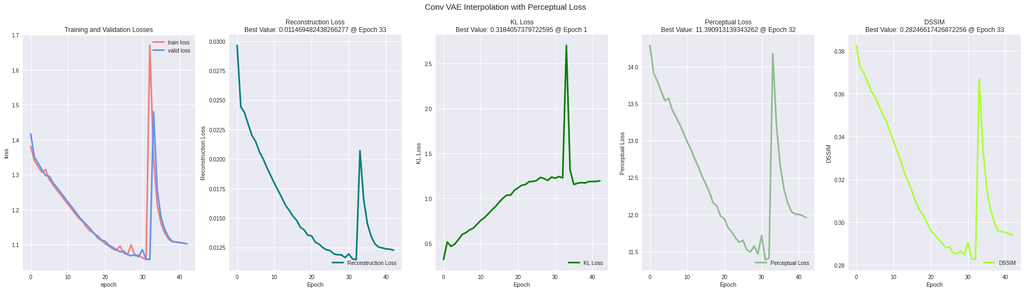

```python
criterion = VAE_CRITERION(lambda_kl=BETA*LATENT_DIM/(3*32*32), lambda_r=10., lambda_dssim=1., lambda_p=0.05)
model = ConvVAE(z_dim=LATENT_DIM, mode='upConv')
model.freeze_encoder()
title = 'Conv VAE Interpolation with Perceptual Loss'
print('Number of model parameters with frozen encoder:', sum(p.numel() for p in model.parameters() if p.requires_grad))
conv_vae_trainer_warmup = Trainer(model, criterion, train_loader, valid_loader,   description=title+' Warmup', lr=LR*2, n_epochs=30)
conv_vae_trainer_warmup.load_model()
plot_history(conv_vae_trainer_warmup)
model = conv_vae_trainer_warmup.model
model.unfreeze_encoder()
print('Number of model parameters:', sum(p.numel() for p in model.parameters() if p.requires_grad))
conv_vae_trainer = Trainer(model, criterion, train_loader, valid_loader,   description=title, lr=LR)
conv_vae_trainer.load_model()
plot_history(conv_vae_trainer)
```

### Training 6 - Retraining a Model optimizing Perceptual Loss

... and once more using a weight of $1$ for the perceptual loss.

Here we also fine-tuned the trained model using a lower learning rate to get the lowest possible perceptual loss (just out of interest).

```
Using cache found in /home/jannogga/.cache/torch/hub/chenyaofo_pytorch-cifar-models_master
Using cache found in /home/jannogga/.cache/torch/hub/chenyaofo_pytorch-cifar-models_master
```

```
Number of model parameters with frozen encoder: 418293
```

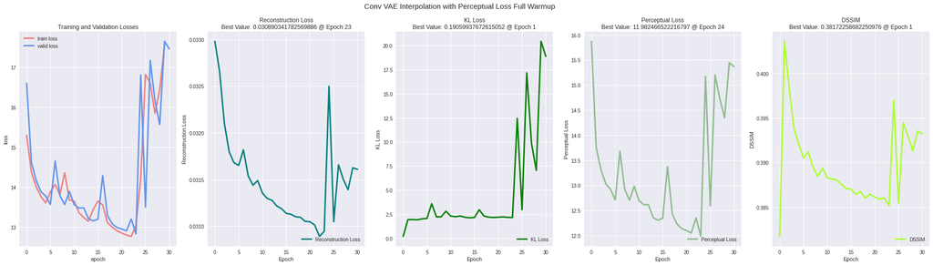

```
Number of model parameters: 690117
```

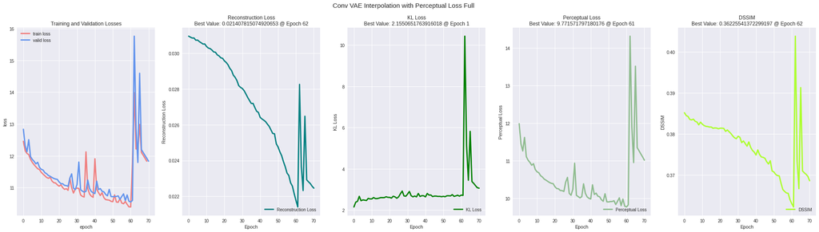

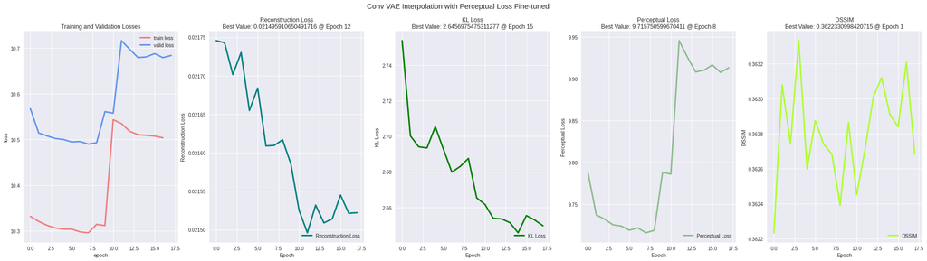

```python
criterion = VAE_CRITERION(lambda_kl=BETA*LATENT_DIM/(3*32*32), lambda_r=10., lambda_dssim=1., lambda_p=1.)
model = ConvVAE(z_dim=LATENT_DIM, mode='upConv')
model.freeze_encoder()
title = 'Conv VAE Interpolation with Perceptual Loss Full'
print('Number of model parameters with frozen encoder:', sum(p.numel() for p in model.parameters() if p.requires_grad))
conv_vae_trainer_warmup = Trainer(model, criterion, train_loader, valid_loader,   description=title+' Warmup', lr=LR*2, n_epochs=30)
conv_vae_trainer_warmup.load_model()
plot_history(conv_vae_trainer_warmup)
model = conv_vae_trainer_warmup.model
model.unfreeze_encoder()
print('Number of model parameters:', sum(p.numel() for p in model.parameters() if p.requires_grad))
conv_vae_trainer = Trainer(model, criterion, train_loader, valid_loader,   description=title, lr=LR)
conv_vae_trainer.load_model()
plot_history(conv_vae_trainer)
title = 'Conv VAE Interpolation with Perceptual Loss Fine-tuned'
model = conv_vae_trainer.model
percept_trainer = Trainer(model, criterion, train_loader, valid_loader,   description=title, lr=0.05*LR)
percept_trainer.load_model()
plot_history(percept_trainer)
```

### Training process conclusion

The training process was more unstable than anticipated. Maybe this is because we used a relatively deep VAE for this task. The reconstructions do not look so great visually, but they are very different depending on whether perceptual loss was used or not. However, it was probably difficult to get good results here anyhow, as CIFAR10 is small on the one hand, but shows a large variety of different objects on the other.

It is also noteworthy that in most training runs the DSSIM and Perceptual Loss curves are very similar. However, we will see below that optimizing perceptual loss produces a different kind of reconstruction that optimizing just DSSIM.

### Visualizing some results

In this section we constrain our discussion to just the interpolating ConvVAEs trained with and without perceptual loss.

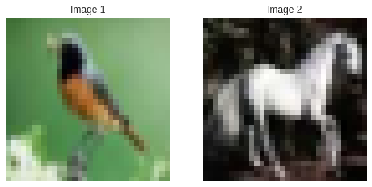

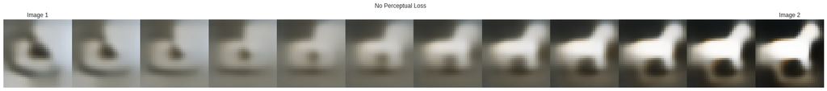

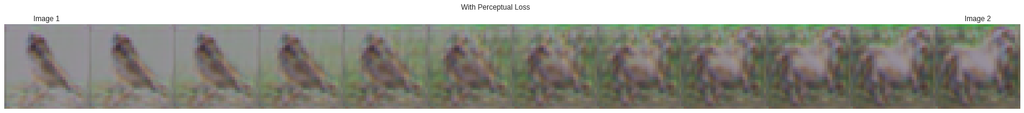

```python
# get two images from the validation set
img1, _ = validset[75]#interesting: 11, 9
img2, _ = validset[13]

plt.subplot(1,2,1)
plt.imshow(img1.unsqueeze(0).squeeze().permute(1, 2, 0))
plt.axis("off")
plt.title("Image 1")
plt.subplot(1,2,2)
plt.imshow(img2.unsqueeze(0).squeeze().permute(1, 2, 0))
plt.axis("off")
plt.title("Image 2")
plt.show()

# 'interpolate' between these two images
device = torch.device("cuda" if torch.cuda.is_available() else "cpu")
for trainer, title in [(interpolate_vae_trainer, 'No Perceptual Loss'), (percept_trainer, 'With Perceptual Loss')]:
    with torch.no_grad():
        encoded = trainer.model.encoder(torch.stack([img1, img2]).to(device))
        mus, log_var = trainer.model.fc_mu(encoded), trainer.model.fc_sigma(encoded)
    std = torch.exp(0.5*log_var)
    latents = mus + std
    latent1, latent2 = latents[0], latents[1]
    # Just the function from the class
    decoded_imgs = sample_interpolation(trainer.model, latent2, latent1, N=12)
    decoded_imgs = nn.Sigmoid()(decoded_imgs)

    fig, ax = plt.subplots(1, len(decoded_imgs), figsize=(30,3))
    fig.suptitle(title)
    for i,img in enumerate(decoded_imgs):
        ax[i].imshow(img.permute(1, 2, 0), cmap="gray")
        ax[i].set(xticklabels=[], yticklabels=[], xticks=[], yticks=[])

    plt.subplots_adjust(wspace=0., hspace=0)
    ax[0].set_title("Image 1")
    ax[-1].set_title("Image 2")
    plt.show()
```

Neither result is really great, but the one without perceptual loss has lost almost all of the structure in the image, whereas at least for the second image, the color is at fine. The model trained with perceptual loss produces an entirely different bird that the one shown in image 1, but then transforms it into a very fat horse which seems inspired by some psychedelic experience. The colors used here by the latter model seem completely made up.

It is also very possible that the dimensionality we used for the latent space ($z \in \mathbb{R}^{28}$) was too low, or the KL loss contributed too much. We find further hints at this if we look at some additional reconstructions from the model trained without perceptual loss. Take for example the two images below, which look completely different.

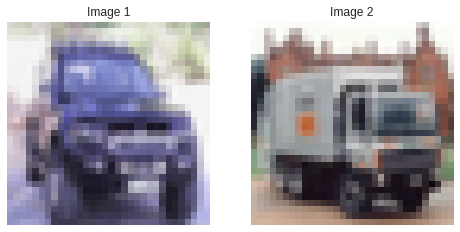

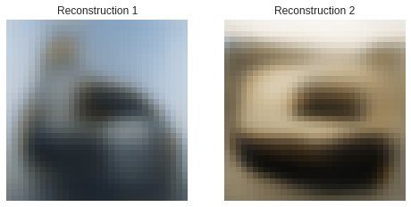

```python
img1, _ = validset[9]
img2, _ = validset[11]

plt.subplot(1,2,1)
plt.imshow(img1.unsqueeze(0).squeeze().permute(1, 2, 0))
plt.axis("off")
plt.title("Image 1")
plt.subplot(1,2,2)
plt.imshow(img2.unsqueeze(0).squeeze().permute(1, 2, 0))
plt.axis("off")
plt.title("Image 2")
plt.show()

# encode and decode them
with torch.no_grad():
    encoded = interpolate_vae_trainer.model.encoder(torch.stack([img1, img2]).to(device))
    mus, log_var = interpolate_vae_trainer.model.fc_mu(encoded), interpolate_vae_trainer.model.fc_sigma(encoded)
    std = torch.exp(0.5*log_var)
    latents = mus + std
    decoded = interpolate_vae_trainer.model.decoder(latents)
decoded1, decoded2 = torch.sigmoid(decoded[0].cpu()), torch.sigmoid(decoded[1].cpu())

plt.subplot(1,2,1)
plt.imshow(decoded1.unsqueeze(0).squeeze().permute(1, 2, 0))
plt.axis("off")
plt.title("Reconstruction 1")
plt.subplot(1,2,2)
plt.imshow(decoded2.unsqueeze(0).squeeze().permute(1, 2, 0))
plt.axis("off")
plt.title("Reconstruction 2")
plt.show()
```

Both vehicles have collapsed to very similar looking shapes, with some kind of black patch where the windshield was and a lower half colored like in the original image. Clearly, the VAE maps these to similar representations, but they seem insufficient for a visually plausible reconstruction. As mentioned above, we suspect this aspect in particular could be improved upon by better tuning the KL term or the latent space dimensionality, but it could also be a consequence of the dataset being difficult.

### Examining the latent space

First we show the embeddings produced by TSNE as shown in the lab session.

```python
trainer = percept_trainer
imgs_flat, latents, labels = [], [], []
with torch.no_grad():
    for imgs, lbls in valid_loader:
        imgs = imgs.to(device)
        _, (z, _, _) = trainer.model(imgs)
        imgs_flat.append(imgs.cpu().view(imgs.shape[0],-1))
        latents.append(z.cpu())
        labels.append(lbls)

imgs_flat = np.concatenate(imgs_flat)
latents = np.concatenate(latents)
labels = np.concatenate(labels)
```

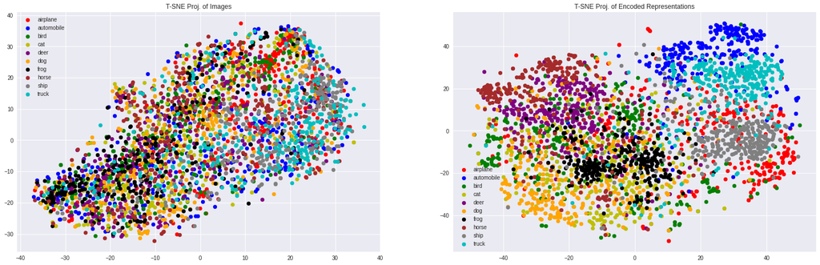

```python
from sklearn.decomposition import PCA
from sklearn.manifold import TSNE

from sklearn.cluster import KMeans
from sklearn.metrics import adjusted_rand_score

N = 3000
tsne_imgs = TSNE(n_components=2).fit_transform(imgs_flat[:N])
tsne_latents = TSNE(n_components=2).fit_transform(latents[:N])

fig,ax = plt.subplots(1,2,figsize=(26,8))
display_projections(tsne_imgs[:N], labels[:N], ax=ax[0], legend=validset.classes)
ax[0].set_title("T-SNE Proj. of Images")
display_projections(tsne_latents[:N], labels[:N], ax=ax[1], legend=validset.classes)
ax[1].set_title("T-SNE Proj. of Encoded Representations")
plt.show()
```

```python
kmeans_imgs = KMeans(n_clusters=10, random_state=0).fit(imgs_flat)
kmeans_latent = KMeans(n_clusters=10, random_state=0).fit(latents)

ari_imgs = adjusted_rand_score(labels, kmeans_imgs.labels_)
ari_latents = adjusted_rand_score(labels, kmeans_latent.labels_)

print(f"Clustering images achieves  ARI={round(ari_imgs*100,2)}%")
print(f"Clustering latents achieves ARI={round(ari_latents*100,2)}%")
```

```
Clustering images achieves  ARI=4.26%
Clustering latents achieves ARI=25.34%
```

While neither clustering is close to the true labels, the latent space representations provide a much better seperation of the classes than without. At the same time, the compression ratio of the image data is very small.

```python
print(f"Compression ratio: {latents.shape[-1]}/{imgs_flat.shape[-1]}  = {round(latents.shape[-1]/imgs_flat.shape[-1] * 100, 2)}%")
```

```
Compression ratio: 28/3072  = 0.91%
```